# Portfolio, EEG

##### Note*

This code is adapted from a project in NESC 3505 and is based off the joint efforts of Nathanael Bowley, Chaojun Ma, Unity Cooper, Noah Derrick and myself.

#### Background

```python
gavg = {}
for index, value in enumerate(conditions):
    gavg[value] = mne.grand_average([evoked[subj][index] for subj in evoked.keys()])
```

```
Identifying common channels ...
Identifying common channels ...
```

#### Plotting the maps

Using a loop and the MNE package, we can plot through each condition of interest while specifying the time range of interest. We expect a much more negative response during the 400-600ms range (known as the N400 paradigm), so we will plot each 100ms for 300-700ms to visualize the difference.

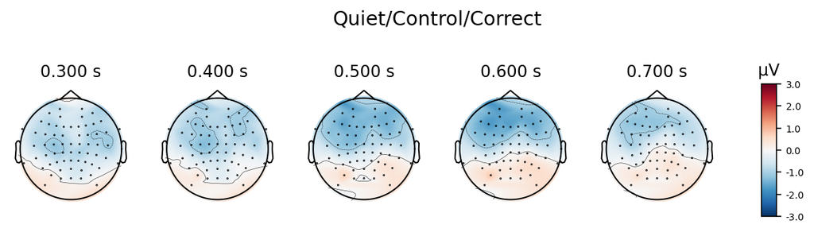

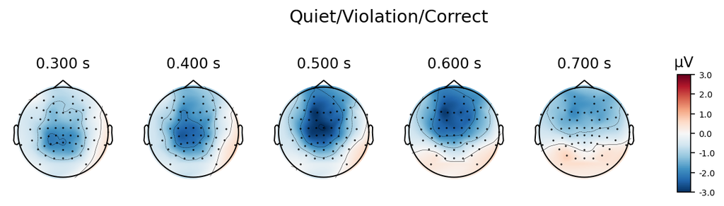

```python
time=np.arange(.300, .700+.001, .100)
for index in gavg.keys():
    gavg[index].plot_topomap(time, average=.200, title=index, vmin=-3, vmax =3)


plt.show()
```

#### Discussion

As seen in the topographic scalp maps above, the brain is considerably more negative in the violation condition, and peaks during the 400-600ms window indicating an N400 response may be present.